# Prova 2 - Análise exploratória de dados

Paulo Ricardo Seganfredo Campana

23 de Outubro de 2021

Questão 01 - Letra A

```r
q1x<-c(2,1,8,4,5,9,3,3,4,9)
```

Questão 01 - Letra B

```r
q1e<-as.factor(c(2,1,2,1,2,1,2,2,1,2))
```

Questão 01 - Letra C

```r
q1x[3]
```

```
## [1] 8
```

Questão 01 - Letra D

```r
q1e[10]
```

```
## [1] 2
## Levels: 1 2
```

Questão 01 - Letra E

```r
q1banco=data.frame(X=q1x,E=q1e)
q1banco
```

```
##    X E
## 1  2 2
## 2  1 1
## 3  8 2
## 4  4 1
## 5  5 2
## 6  9 1
## 7  3 2
## 8  3 2
## 9  4 1
## 10 9 2
```

Questão 01 - Letra F

```r
q1banco[5,]
```

```
##   X E
## 5 5 2
```

Questão 01 - Letra G

```r
q1banco[,1]
```

```
##  [1] 2 1 8 4 5 9 3 3 4 9
```

Questão 01 - Letra H

```r
tapply(q1x,q1e,mean)
```

```
##   1   2
## 4.5 5.0
```

Questão 01 - Letra I

```r
sum(q1x^2)
```

```
## [1] 306
```

Questão 01 - Letra J

```r
mean(q1x)
```

```
## [1] 4.8
```

Questão 01 - Letra K

q1e<-as.factor(q1e), já feito na letra B

Questão 2

```r
aleatorio<-function(obj){
  v<-ifelse(obj>4,1,0)
  soma<-sum(v)
  p<-sum(v)/length(obj)
  return(p)}
```

Questão 2 - Letra A

A função atribui valor 1 para elementos de um vetor que são maiores que 4, e 0 para menores que 4, é então feito a média desses valores e o resultado é direcionado ao console. A função pode ser interpretada como a porcentagem de valores maiores que 4 de um vetor.

Questão 2 - Letra B Os únicos valores de X maiores que 4 são: 8, 5, 9 e 9, é atribuido 1 a estes 4 valores e 0 aos demais 6, a média resultará em “0.4”.

```r
aleatorio(q1x)
```

```
## [1] 0.4
```

Questão 3

```r
q3y<-c(3.9,2.2,3.7,2.5,2.4,2.3,2.5,2,2,1.4)
q3x<-c(50,38,48,36,34,34,36,30,31,29)
```

Questão 3 - Letra A

```r
data.frame("Variável"=c("Peso","Tamanho"),
           "Média"=c(mean(q3y),mean(q3x)))
```

```
##   Variável Média
## 1     Peso  2.49
## 2  Tamanho 36.60
```

Questão 3 - Letra B

```r
data.frame("Variável"=c("Peso","Tamanho"),
           "Variância"=c(var(q3y),var(q3x)),
           "Desvio Padrão"=c(sd(q3y),sd(q3x)))
```

```
##   Variável  Variância Desvio.Padrão
## 1     Peso  0.5832222     0.7636899
## 2  Tamanho 50.9333333     7.1367593
```

Questão 3 - Letra C

Os valores de Y e X estão em magnitudes diferentes, usa-se a o coeficiente de variação. O valor X possúi menor variação.

```r
cv<-function(v){sd(v)/mean(v)}
cv(q3y)
```

```
## [1] 0.3067028
```

```r
cv(q3x)
```

```
## [1] 0.1949934
```

Questão 3 - Letras D e E

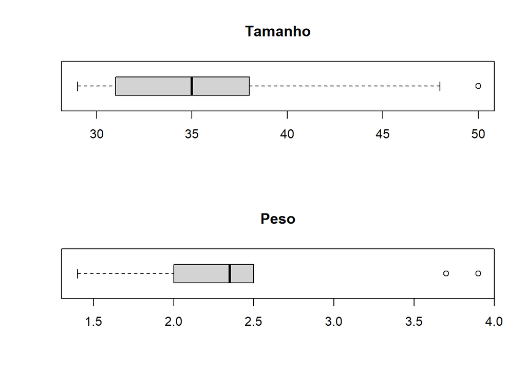

```r
par(mfrow=c(2,1))
boxplot(q3x,horizontal=TRUE,main="Tamanho")
boxplot(q3y,horizontal=TRUE,main="Peso")
```

```r
par(mfrow=c(1,1))
```

Questão 3 - Letra F

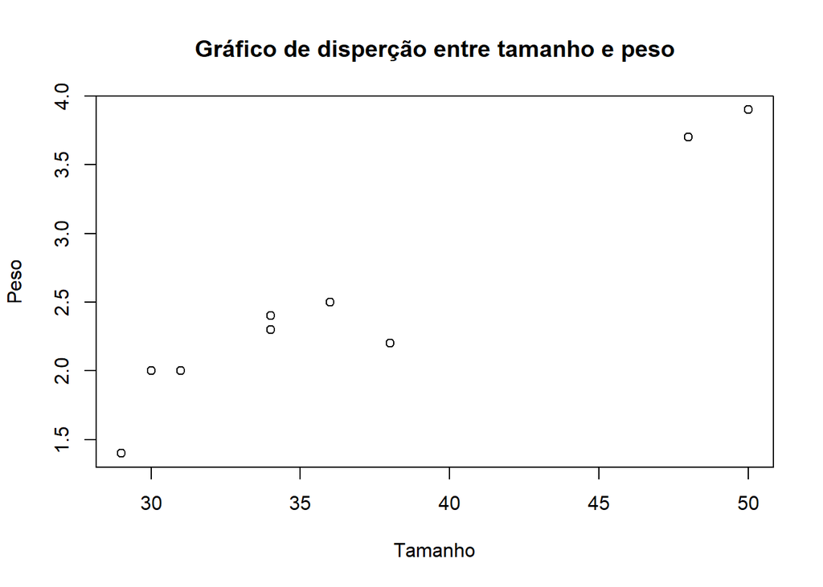

```r
plot(q3x,q3y,main="Gráfico de disperção entre tamanho e peso",
     xlab="Tamanho",ylab="Peso")
```

Questão 3 - Letra G

Correlação = 96%, forte indício de correlação entre as variáveis.

```r
cor(q3x,q3y)
```

```
## [1] 0.9634588
```

Questão 3 - Letra H

```r
asymmetry=function(v,numerador){
  (sqrt(length(v)/(length(v)-1)))*(1/(length(v)-1))*(numerador/sd(v)^3)}

data.frame("Variável"=c("Tamanho","Peso"),
           "Assimetria"=c(asymmetry(q3x,2952.72),asymmetry(q3y,3.013)))
```

```
##   Variável Assimetria
## 1  Tamanho  0.9513829
## 2     Peso  0.7922902
```

Questão 3 - Letra I

```r
kurtosis=function(v,numerador){
  (length(v)/(length(v)-1)^2)*(numerador/var(v)^2)-3}

data.frame("Variável"=c("Tamanho","Peso"),
           "Curtose"=c(kurtosis(q3x,55444.03),kurtosis(q3y,7.63)))
```

```
##   Variável    Curtose
## 1  Tamanho -0.3614485
## 2     Peso -0.2306912
```

Questão 3 - Letra J

a = -1.2834 b = 0.1031

```r
lm(q3y~q3x)$coefficients
```

```
## (Intercept)         q3x
##  -1.2833770   0.1030977
```

Questão 3 - Letra K

Sim, porque 92.8% da variação de Y pode ser explicada por X (Multiple R-squared: 0.928)

```r
summary(lm(q3y~q3x))$r.squared
```

```
## [1] 0.9282528
```

Questão 3 - Letra L

Se estes valores são de magnitude baixa, fornece evidência que o modelo linear representa bem os dados.

```r
0.001+0.189+0.001+0.005+0.032+0.006+0.005+0.0036+0.008+0.094
```

```
## [1] 0.3446
```

Questão 3 - Letra M

Usando os coeficientes da regressão linear, podemos criar uma função de peso estimado em relação ao tamanho.

```r
q3<-function(x){
  lm(q3y~q3x)$coefficients[1]+lm(q3y~q3x)$coefficients[2]*x}

data.frame("Variável"=c("Tamanho","Peso estimado"),
           "Bebê 1"=c(46,q3(46)),
           "Bebê 2"=c(35,q3(35)),
           "Bebê 3"=c(49,q3(49)))
```

```
##                  Variável    Bebê.1    Bebê.2    Bebê.3
##                   Tamanho 46.000000 35.000000 49.000000
## (Intercept) Peso estimado  3.459119  2.325044  3.768412
```

Questão 3 - Letra N

Y = X*b

```r
Y = matrix(lm(q3y~q3x)$fitted.values,nrow=10,ncol=1)
Y
```

```
##           [,1]
##  [1,] 3.871510
##  [2,] 2.634337
##  [3,] 3.665314
##  [4,] 2.428141
##  [5,] 2.221946
##  [6,] 2.221946
##  [7,] 2.428141
##  [8,] 1.809555
##  [9,] 1.912653
## [10,] 1.706457
```

```r
X = matrix(c(1,1,1,1,1,1,1,1,1,1,q3x),nrow=10,ncol=2)
X
```

```
##       [,1] [,2]
##  [1,]    1   50
##  [2,]    1   38
##  [3,]    1   48
##  [4,]    1   36
##  [5,]    1   34
##  [6,]    1   34
##  [7,]    1   36
##  [8,]    1   30
##  [9,]    1   31
## [10,]    1   29
```

```r
b = matrix(lm(q3y~q3x)$coefficients,nrow=2,ncol=1)
b
```

```
##            [,1]
## [1,] -1.2833770
## [2,]  0.1030977
```

X*b - Y = 0

```r
X %*% b - Y
```

```
##                [,1]
##  [1,]  2.664535e-15
##  [2,] -1.332268e-15
##  [3,]  0.000000e+00
##  [4,]  0.000000e+00
##  [5,] -4.440892e-16
##  [6,] -4.440892e-16
##  [7,]  0.000000e+00
##  [8,] -2.220446e-16
##  [9,]  2.220446e-16
## [10,] -2.220446e-16
```

Questão 4

Objetivo: “Estimar a proporção de pessoas que estão infectadas com COVID-19 na cidade de João Pessoa para o planejamento de ações sociais referentes às famílias.”

Usar a PNAD COVID19, uma pesquisa domiciliar já feita como base, pode ser acessada em: https://biblioteca.ibge.gov.br/visualizacao/instrumentos_de_coleta/doc5592.pdf

Algumas questões se referem-se a detecção do COVID, porém a questão 4 assume que os moradores já tenham feito o teste em domicílio.

Outros tipos de perguntas são as referentes a atividades escolares, trabalho, recebimento de pensão, empréstimos e alugel, que embora importantes, não estão no escopo atual e deixariam o questionário muito longo.

Nos resta questões do tipo: idade, sexo, cor/raça, escolaridade, situação econômica e questões referentes a presença de coronavirus no domicílio.

Devido a pesquisa ser feita a mais de um ano atrás, algumas perguntas novas devem ser adicionadas como as referentes sobre ter tido o vírus no passado porém recuperado, se teve parentes que morreram de covid, se já foram vacinados e quantas doses, se pretendem vacinar.

Ficam então com as seguintes variáveis a ser consideradas:

- Moradores do domicílio (Valor inteiro positivo)
- Idade (Valor em anos)
- Sexo (Homem/Mulher/Outro)
- Cor/Raça (Branca/Preta/Amarela/Parda/Indígena)
- Escolaridade (Sem instrução/Fundamental/Médio/Superior/Pós-graduação)
- Renda do domicílio (Valor em Reais)
- Ter covid atualmente (Sim/Não/Não sei)
- Ter tido covid e recuperado (Sim/Não)
- Mortes por covid no domicílio (Valor inteiro positivo)
- Estado de vacinação (Ainda não vacinado/1ª dose/2ª dose/Não irei tomar)